## Lab 3 - Distributions of Random Variables

#### By Brian Weinfeld

##### February 18, 2018

### Exercises

#1: Make a histogram of men’s heights and a histogram of women’s heights. How would you compare the various aspects of the two distributions?

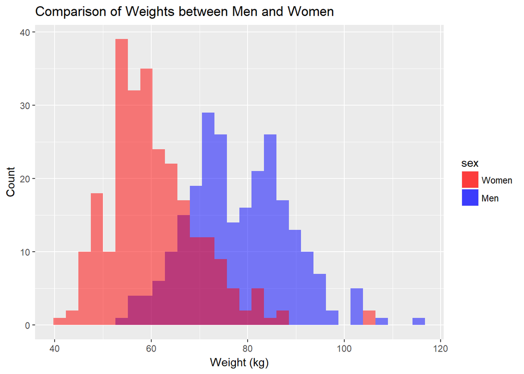

```r
mdims <- subset(bdims, sex == 1)
fdims <- subset(bdims, sex == 0)
ggplot() + geom_histogram(data=mdims, aes(x=wgt, fill=sex), alpha=0.5) +
  geom_histogram(data=fdims, aes(x=wgt, fill=sex), alpha=0.5) +
  labs(x='Weight (kg)', y='Count', title='Comparison of Weights between Men and Women') +
  scale_fill_manual(name='sex', values=c('red', 'blue'), labels=c('Women', 'Men'))
```

```r
summary(mdims$wgt)
```

```
##    Min. 1st Qu.  Median    Mean 3rd Qu.    Max.
##   53.90   70.95   77.30   78.14   85.50  116.40
```

```r
sd(mdims$wgt)
```

```
## [1] 10.51289
```

```r
summary(fdims$wgt)
```

```
##    Min. 1st Qu.  Median    Mean 3rd Qu.    Max.
##    42.0    54.5    59.0    60.6    65.6   105.2
```

```r
sd(fdims$wgt)
```

```
## [1] 9.615699
```

Men weigh more than women and have a larger standard deviation and IQR indicating that men’s weights vary more than womens. Both distributions look roughly normal, but further analysis would be required to know for certain.

#2: Based on the this plot, does it appear that the data follow a nearly normal distribution?

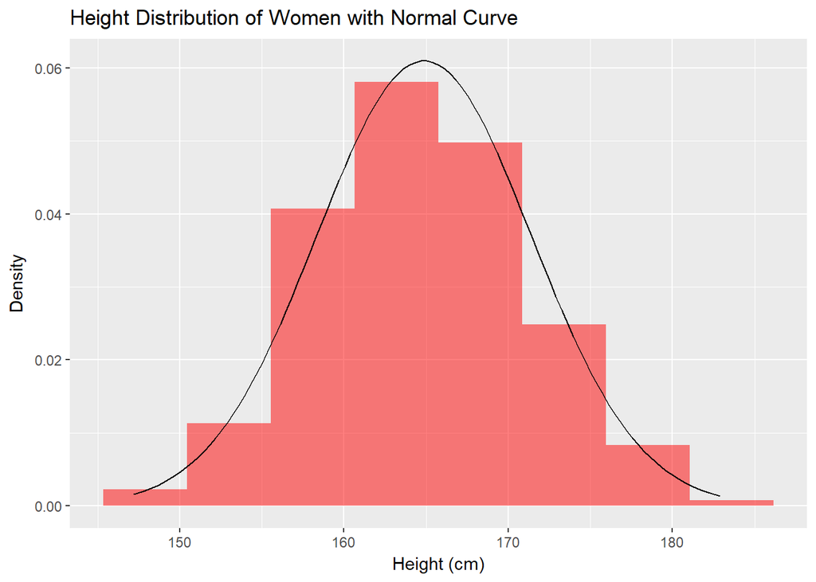

```r
fhgtmean <- mean(fdims$hgt)
fhgtsd <- sd(fdims$hgt)

ggplot(data=fdims, aes(x=hgt)) + geom_histogram(aes(y=..density..), fill='red', alpha=0.5, bins=8) +
  stat_function(fun=dnorm, args=list(mean=fhgtmean, sd=fhgtsd)) +
  labs(x='Height (cm)', y='Density', title='Height Distribution of Women with Normal Curve')
```

Yes, the data appears to closely resemble the normal curve.

#3: Make a normal probability plot of sim_norm. Do all of the points fall on the line? How does this plot compare to the probability plot for the real data?

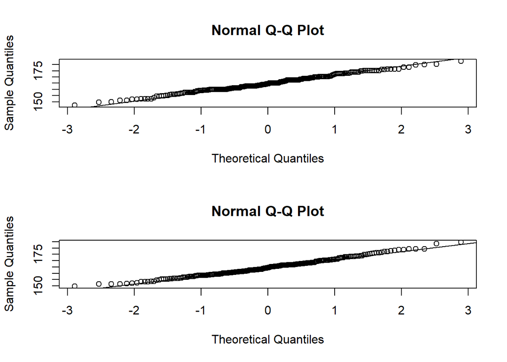

```r
par(mfrow=c(2,1))
qqnorm(fdims$hgt)
qqline(fdims$hgt)

sim_norm <- rnorm(n = length(fdims$hgt), mean = fhgtmean, sd = fhgtsd)
qqnorm(sim_norm)
qqline(sim_norm)
```

No, all the points do not fall on the line. The real data appears to have more variations than the simulated data but stays pretty close to the line. Both deviate at the extremes although in different directions.

#4: Does the normal probability plot for fdims$hgt look similar to the plots created for the simulated data? That is, do plots provide evidence that the female heights are nearly normal?

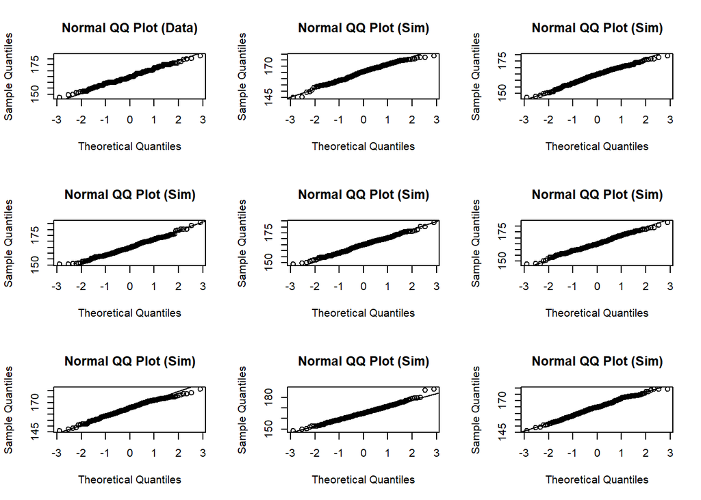

```r
qqnormsim(fdims$hgt)
```

Yes, the data looks similar to the simulated data. The highest and lowest extremes deviate a bit but represent a very small portion of the overall data.

#5: Using the same technique, determine whether or not female weights appear to come from a normal distribution.

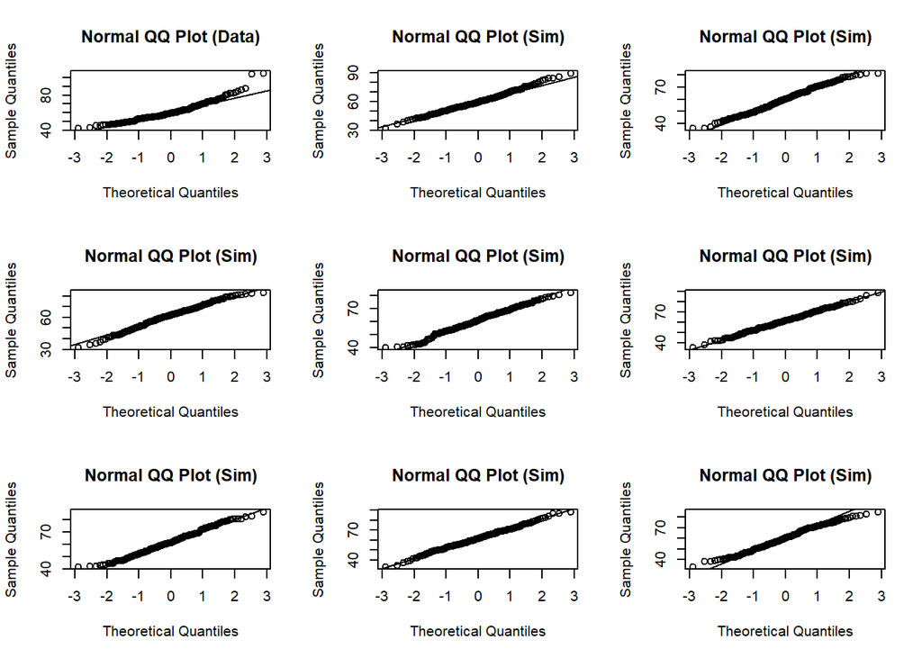

```r
qqnormsim(fdims$wgt)
```

No. The data does not appear similar. The actual data has many more extreme values both on the high end and low end. It is logical to say that women’s weight in this data is not normally distributed.

#6: Write out two probability questions that you would like to answer; one regarding female heights and one regarding female weights. Calculate the those probabilities using both the theoretical normal distribution as well as the empirical distribution (four probabilities in all). Which variable, height or weight, had a closer agreement between the two methods?

Question 1: What is the probability that a randomly selected young adult female is shorter than 5 feet (152.4 cm)?

```r
pnorm(q=152.4, mean=fhgtmean, sd=fhgtsd)
```

```
## [1] 0.028342
```

```r
sum(fdims$hgt <= 152.4) / length(fdims$hgt)
```

```
## [1] 0.04230769
```

Question 2: What is the probability that a randomly selected young adult female weights more than 80kgs?

```r
pnorm(q=80, mean=fdims$wgt %>% mean(), sd=fdims$wgt %>% sd(), lower.tail=FALSE)
```

```
## [1] 0.02182199
```

```r
sum(fdims$wgt > 80) / length(fdims$wgt)
```

```
## [1] 0.04230769
```

The calculation on height was more accurate. This makes sense as the height distribution is more roughly normal than the weight distribution.

### On Your Own

#1: Now let’s consider some of the other variables in the body dimensions data set. Using the figures at the end of the exercises, match the histogram to its normal probability plot. All of the variables have been standardized (first subtract the mean, then divide by the standard deviation), so the units won’t be of any help. If you are uncertain based on these figures, generate the plots in R to check.

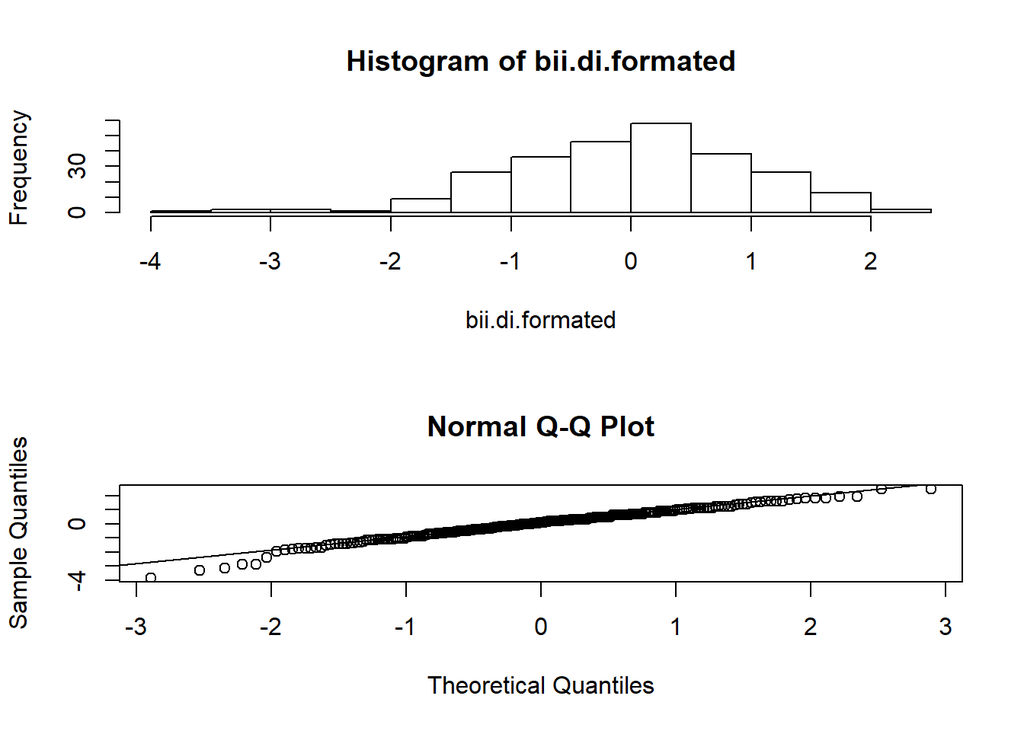

```r
par(mfrow=c(2,1))
bii.di.formated <- ((fdims$bii.di) - mean(fdims$bii.di)) / sd(fdims$bii.di)
hist(bii.di.formated, breaks=13)
qqnorm(bii.di.formated)
qqline(bii.di.formated)
```

bii.di matches with Q-Q Plot B. There are too many lower outliers for the data to be normal.

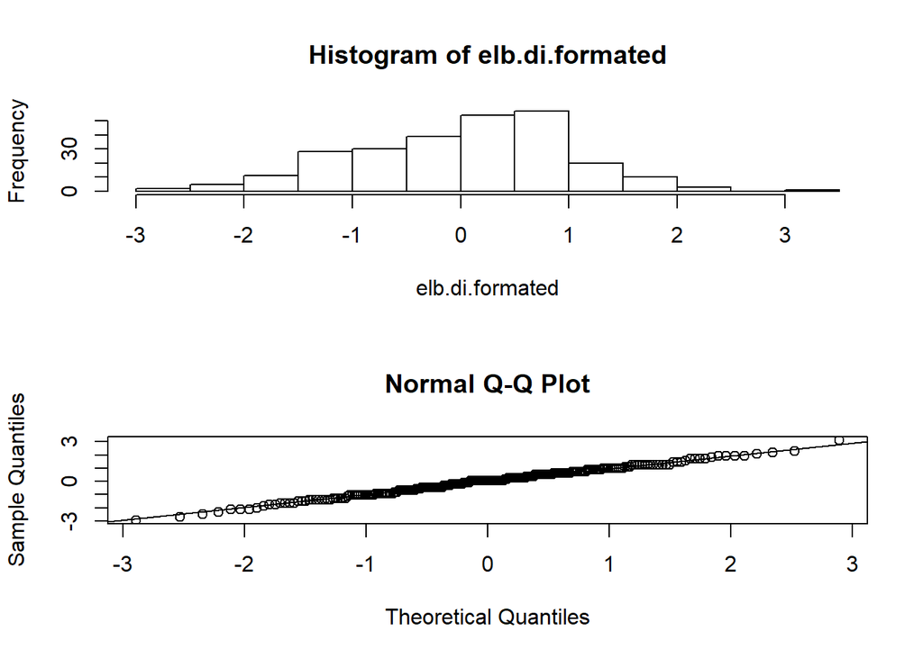

```r
par(mfrow=c(2,1))
elb.di.formated <- ((fdims$elb.di) - mean(fdims$elb.di)) / sd(fdims$elb.di)
hist(elb.di.formated, breaks=13)
qqnorm(elb.di.formated)
qqline(elb.di.formated)
```

elb.di matches with Q-Q Plot C. This data is the most normally distributed and thus should match with the Q-Q plot closest to a straight line.

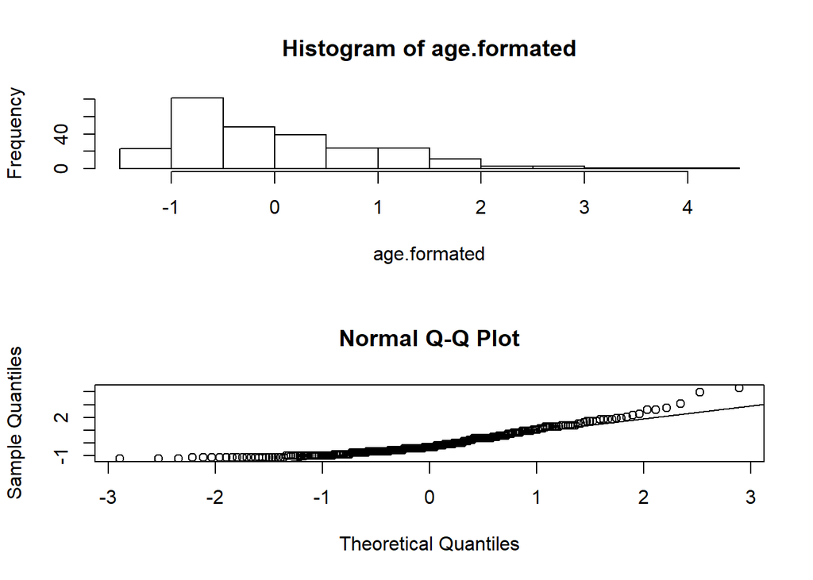

```r
par(mfrow=c(2,1))
age.formated <- ((fdims$age) - mean(fdims$age)) / sd(fdims$age)
hist(age.formated, breaks=13)
qqnorm(age.formated)
qqline(age.formated)
```

age matches with Q-Q Plot D. The data is heavily skew right and that is reflected in the Q-Q Plot.

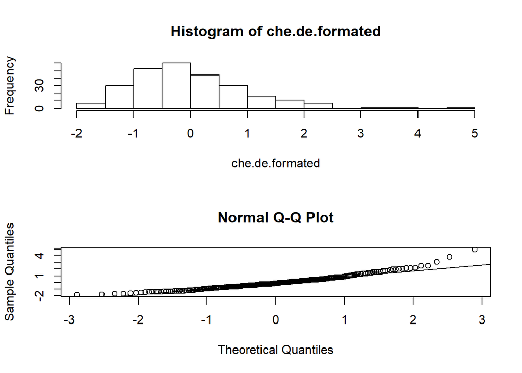

```r
par(mfrow=c(2,1))
che.de.formated <- ((fdims$che.de) - mean(fdims$che.de)) / sd(fdims$che.de)
hist(che.de.formated, breaks=13)
qqnorm(che.de.formated)
qqline(che.de.formated)
```

che.de matches with Q-Q Plot A. The data has the most upper outliers and this is reflected in the upper values of the Q-Q Plot.

#2: Note that normal probability plots C and D have a slight stepwise pattern. Why do you think this is the case?

Age is usually rounded to the nearest year and thus is likely to result in many repeated values.

Female elbow diameter is unlikely to be rounded but perhaps there are just not that many variations in elbow diameter when compared to other measurements.

#3: As you can see, normal probability plots can be used both to assess normality and visualize skewness. Make a normal probability plot for female knee diameter (kne.di). Based on this normal probability plot, is this variable left skewed, symmetric, or right skewed? Use a histogram to confirm your findings.

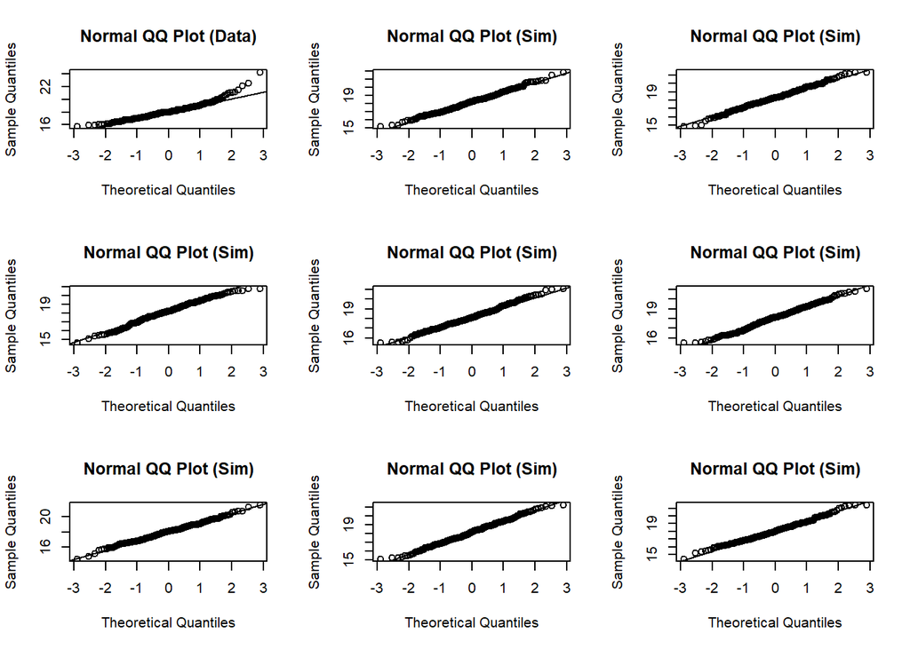

```r
qqnormsim(fdims$kne.di)
```

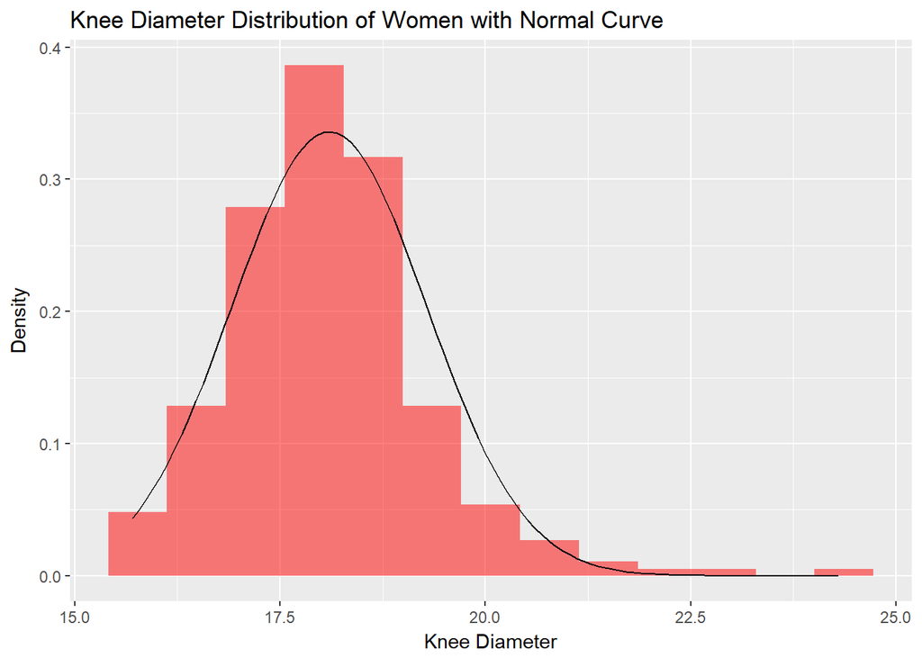

```r
ggplot(data=fdims, aes(x=kne.di)) + geom_histogram(aes(y=..density..), fill='red', alpha=0.5, bins=13) +
  stat_function(fun=dnorm, args=list(mean=fdims$kne.di %>% mean(), sd=fdims$kne.di %>% sd())) +
  labs(x='Knee Diameter', y='Density', title='Knee Diameter Distribution of Women with Normal Curve')
```

The data is not normally distributred and appears to be skew right.